# Lab 7 - Space Use and Resource Selection

ECOL 620 - Applications in Landscape Ecology

George Woolsey

30 March, 2023

# Setup

```r
# bread-and-butter
library(tidyverse)
library(lubridate)
library(viridis)
library(scales)
library(latex2exp)
# visualization
library(kableExtra)
library(cowplot)
library(RColorBrewer)
library(ggnewscale) # add second scale color/fill
# spatial analysis
library(terra)
library(adehabitatLT)     #for trajectory information; version 0.3.23 used
library(adehabitatHR)     #Home range estimation; version 0.4.15 used
library(adehabitatHS)     #for selection ratios; version 0.3.13 used
library(maptools) ## one of these adehabitat needs this
# do i have to???
# library(raster)           #for raster covariate data; version 2.6-7 used
# library(rgdal)            #for reading different types of GIS files; version 1.3-4 used
# set seed
set.seed(11)
```

# Rules

1. Using the provided R Markdown template, answer all questions and show your R code where necessary. Note, some questions are just plain text written answers.
2. Complete your assignment using the R markdown file and submit individual assignments to Canvas. Knit your script and submit an .html file on Canvas. Please use the following naming convention: lab5_firstname_lastname.html (ex. lab7_kyle_horton.html). Note, we will not grade labs in any other format.

# Florida panther home range

## Load Data

```r
# landcover source: fwc/fnai
land <- terra::rast("../data/panther_landcover.tif")
reproject_crs <- terra::crs(land)
terra::freq(land)
# Add panther data
panthers <- sf::st_read("../data/panthers.shp") |>
  sf::st_transform(reproject_crs) |>
  dplyr::select(-c(X,Y)) |>
  dplyr::mutate(CatID = as.factor(CatID))
#inspect
str(panthers)
# counts
panthers |>
  sf::st_drop_geometry() |>
  dplyr::count(CatID)
panthers |>
  sf::st_drop_geometry() |>
  dplyr::count(AgeClass)
panthers |>
  sf::st_drop_geometry() |>
  dplyr::count(CatID,AgeClass)
# plot
ggplot() +
  geom_raster(
    data = land |> as.data.frame(xy=T) |> dplyr::rename(covertyp=3)
    , mapping = aes(x=x,y=y,fill=covertyp)
  ) +
  geom_sf(data = panthers, mapping = aes(color = CatID)) +
  scale_fill_viridis_c(alpha = 0.8) +
  scale_color_viridis_d(option = "magma") +
  theme_light()
```

Reclassify the land cover data based on classification matrix

```r
# reclass
# load reclassification to resistance surface
landcover_reclass <- read.table("../data/landcover reclass.txt", header = T) |>
  dplyr::rename_with(tolower)
landcover_reclass |>  dplyr::glimpse()
# create landcover surface raster
rcl_matrix <- landcover_reclass |>  dplyr::select(landcover, changeto) |>  as.matrix()
land_sub <- terra::classify(land, rcl = rcl_matrix)
# investigate
land |>  terra::unique() |>  nrow()
land_sub |>  terra::unique() |>  nrow()
plot(land_sub)
```

```r
#create forested wetlands layer
wetforest <- land_sub
terra::values(wetforest) <- 0
wetforest[land_sub %in% c(9,11)] <- 1
plot(wetforest)
```

```r
#create forested uplands layer
dryforest <- land_sub
terra::values(dryforest) <- 0
dryforest[land_sub %in% c(10,12)] <- 1
plot(dryforest)
```

```r
# create moving window calculation of different forest types
fw <- terra::focalMat(land_sub, d = 5000, type = "circle")
dry.focal <- terra::focal(dryforest, w = fw, fun = "sum", na.rm=T)
wet.focal <- terra::focal(wetforest, w = fw, fun = "sum", na.rm=T)
plot(dry.focal)
```

```r
plot(wet.focal)
```

## Question 1

Within the “panthers” SpatialPointsDataFrame, there are three columns of information. Describe what each represents. (3 pts)

The “panthers.shp” data includes radiotelemetry data from Florida panthers (*Puma concolor coryi*) in south Florida with the columns **CatID, Juldate, AgeClass**. Data come from six panthers identified by the column `CatID`, three subadults and three adults denoted in the data column `AgeClass`, that were tracked during 2006 with dates identified by the column `Juldate`.

## Question 2

Describe what lines 102-104 are achieving. What is “fw” and how is it used in the “focal” function? (4 pts)

```r
fw <- raster::focalWeight(land_sub, 5000, 'circle')
dry.focal <- raster::focal(dryforest, w=fw, fun="sum", na.rm=T)
wet.focal <- raster::focal(wetforest, w=fw, fun="sum", na.rm=T)
```

The `raster::focalWeight` function calculates a “moving window” weight matrix in which the values add up to one, named `fw`, in a 5 km radius (5,000 m) for use in the `raster::focal` function. The `raster::focal` function calculates the focal (“moving window”) values for the neighborhood of focal cells using a matrix of weights and sums the weighted amount of each forest type within the 5 km radius.

## Question 3

Plot the minimum convex polygon for panther #137. Show the raw locations (points) and the 50%, 75%, and 95% minimum convex polygons. See the example on Canvas for reference. (5 pts)

```r
# take panthers and select the column of the data frame that
  # includes the animal identification number (CatID) to
  # calculate Minimum Convex Polygons with the mcp function
# :'( :'( :'(  :'( :'( :'(  :'( :'( :'(  :'( :'( :'(
# have to convert from sf to sp object to use mcp
sp_panthers_temp <- sf::as_Spatial(panthers)
# function to pass to mcp
my_mcp_fn <- function(pct) {
  adehabitatHR::mcp(
    sp_panthers_temp[,"CatID"]
    , percent = pct
  ) |>
  sf::st_as_sf()
}
# pcts for minimum convex polys
pct_list <- c(95,75,50)
# create sf object with all pcts in one for plotting
min_convex_polys <- pct_list |>
  purrr::map(my_mcp_fn) |>
  dplyr::bind_rows(.id = "column_label") |>
  dplyr::mutate(
    pct_grp = factor(
      column_label
      , labels = paste0(pct_list,"%")
      , ordered = T
    )
  )
```

Plot for panther #137

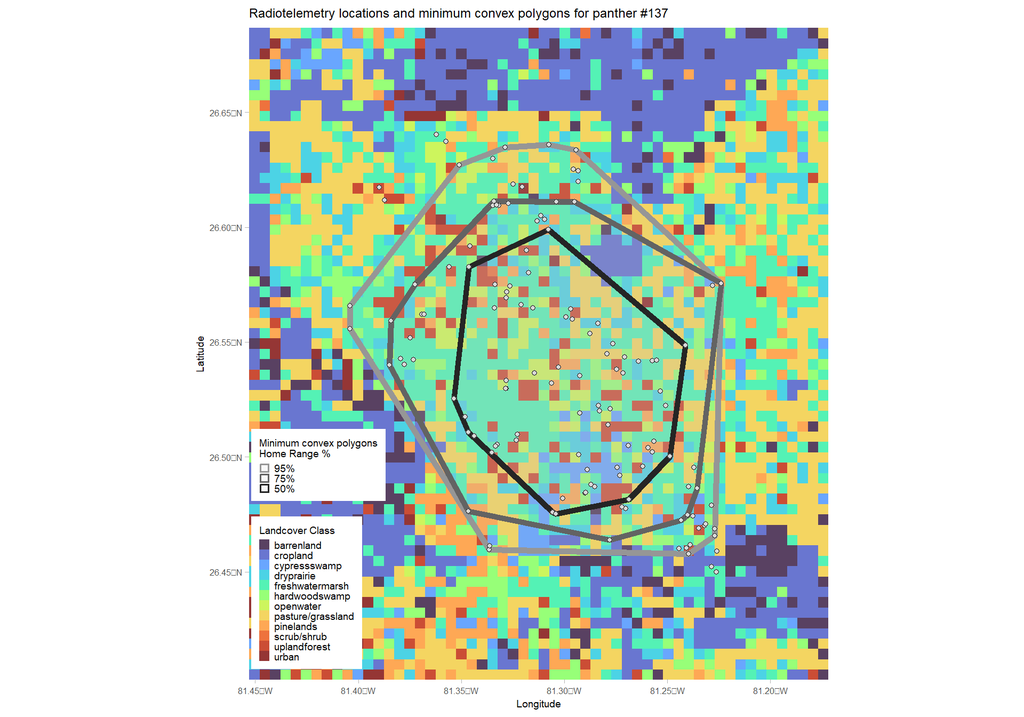

```r
panther_filter_temp <- "137"
# create df of landcover reclass raster
land_sub_df_temp <- land_sub |>
  terra::crop(
    panthers |>
      dplyr::filter(CatID == panther_filter_temp) |>
      sf::st_bbox() |>
      sf::st_as_sfc() |>
      sf::st_buffer(5000) |>
      terra::vect()
  ) |>
  as.data.frame(xy=T) |>
  dplyr::rename(landcover_type=3) |>
  dplyr::left_join(
    landcover_reclass |>
      dplyr::count(changeto,description2)
    , by = c("landcover_type"="changeto")
  ) |>
  dplyr::mutate(
    landcover_class = as.factor(description2)
  )
#plot
ggplot() +
  geom_raster(
    data = land_sub_df_temp
    , mapping = aes(x=x,y=y,fill=landcover_class)
  ) +
  geom_sf(
    data = min_convex_polys |> dplyr::filter(id == panther_filter_temp)
    , mapping = aes(color = pct_grp)
    , fill = "gray"
    , alpha = 0.1
    , lwd = 2
  ) +
  geom_sf(
    data = panthers |> dplyr::filter(CatID == panther_filter_temp)
    , color = "black"
    , fill = "gray85"
    , shape = 21
  ) +
  scale_fill_viridis_d(option = "turbo", alpha = 0.8) +
  scale_color_manual(
    values = RColorBrewer::brewer.pal(n = length(pct_list)*2, name = "Greys") |> tail(length(pct_list))
  ) +
  scale_x_continuous(expand = c(0, 0)) +
  scale_y_continuous(expand = c(0, 0)) +
  labs(
    subtitle = paste0("Radiotelemetry locations and minimum convex polygons for panther #", panther_filter_temp)
    , x = "Longitude"
    , y = "Latitude"
    , fill = "Landcover Class"
    , color = "Minimum convex polygons\nHome Range %"
  ) +
  theme_light() +
  theme(
    legend.position = c(0.12, 0.2)
    , legend.key.size = unit(0.25, 'cm')
    , legend.text = element_text(size = 7)
    , legend.title = element_text(size = 7)
    , axis.title = element_text(size = 7)
    , axis.text.y = element_text(size=6)
    , axis.text.x = element_text(size=6)
    , panel.border = element_blank()
    , plot.subtitle = element_text(size=9)
    , panel.grid = element_blank()
  )
```

## Question 4

Plot the minimum convex polygon for all panthers overlaid on the reclassified landcover raster. Show the 50% and 95% minimum convex polygons. See the example on Canvas for reference. (6 pts)

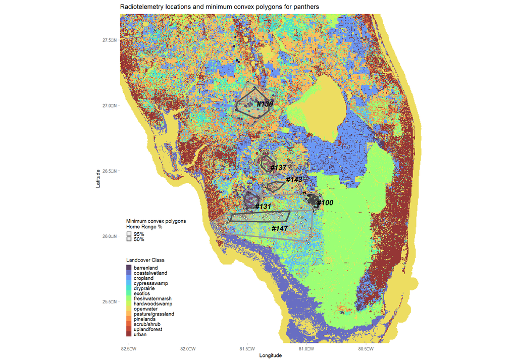

```r
# create df of landcover reclass raster
land_sub_df <- land_sub |>
  as.data.frame(xy=T) |>
  dplyr::rename(landcover_type=3) |>
  dplyr::left_join(
    landcover_reclass |>
      dplyr::count(changeto,description2)
    , by = c("landcover_type"="changeto")
  ) |>
  dplyr::mutate(
    landcover_class = as.factor(description2)
  )
# filter for only some pcts
pct_list_temp <- c("50%","95%")
set.seed(11)
#plot
ggplot() +
  geom_raster(
    data = land_sub_df
    , mapping = aes(x=x,y=y,fill=landcover_class)
  ) +
  scale_fill_viridis_d(option = "turbo", alpha = 0.8) +
  labs(fill = "Landcover Class") +
  # start a new scale fill for points
  ggnewscale::new_scale_fill() +
  geom_sf(
    data = panthers
    , mapping = aes(fill = CatID)
    , color = "black"
    , shape = 21
    , show.legend = F
    , size = 1
  ) +
  scale_fill_viridis_d(option = "magma") +
  # plot min_convex_polys
  geom_sf(
    data = min_convex_polys |> dplyr::filter(pct_grp %in% pct_list_temp)
    , mapping = aes(color = pct_grp)
    , fill = "gray"
    , alpha = 0.2
    , lwd = 1
  ) +
  scale_color_manual(
    values = RColorBrewer::brewer.pal(n = length(pct_list_temp)*2, name = "Greys") |> tail(length(pct_list_temp))
  ) +
  # labels
  ggrepel::geom_text_repel(
    data =
      min_convex_polys |>
        dplyr::filter(pct_grp == "95%") |>
        sf::st_centroid() |>
        dplyr::mutate(id=paste0("#",id))
    , aes(label=id, geometry = geometry)
    , stat = "sf_coordinates"
    , size = 3.5
    , color = "black"
    , fontface = "bold.italic"
    , seed = 11
    , nudge_x = 100
  ) +
  scale_x_continuous(expand = c(0, 0)) +
  scale_y_continuous(expand = c(0, 0)) +
  labs(
    subtitle = paste0("Radiotelemetry locations and minimum convex polygons for panthers")
    , x = "Longitude"
    , y = "Latitude"
    , color = "Minimum convex polygons\nHome Range %"
  ) +
  theme_light() +
  theme(
    legend.position = c(0.12, 0.2)
    , legend.key.size = unit(0.25, 'cm')
    , legend.text = element_text(size = 7)
    , legend.title = element_text(size = 7)
    , axis.title = element_text(size = 7)
    , axis.text.y = element_text(size=6)
    , axis.text.x = element_text(size=6)
    , panel.border = element_blank()
    , plot.subtitle = element_text(size=9)
    , panel.grid = element_blank()
  )
```

## Question 5

For all panthers, create a four-panel plot showing the home ranges as estimated by: minimum convex polygon, fixed bivariate kernel home range, local convex hull home range, and Brownian bridge. For each approach, plot the 95% contours. Hint, for the local convex hull home range, I used the “LoCoH.k” function with a k of 14. (12 pts).

### minimum convex polygon

```r
#plot
plt_minimum_convex_polygon <- ggplot() +
  geom_raster(
    data = land_sub_df
    , mapping = aes(x=x,y=y,fill=landcover_class)
  ) +
  geom_sf(data = panthers, mapping = aes(color = CatID), alpha = 0.5, size = 1, show.legend = F) +
  # plot home range
  geom_sf(
    data = min_convex_polys |> dplyr::filter(pct_grp == "95%")
    , mapping = aes(color = id)
    , fill = "gray"
    , alpha = 0.1
    , lwd = 1
    , show.legend = F
  ) +
  scale_color_viridis_d(option = "magma") +
  scale_fill_viridis_d(option = "turbo", alpha = 0.8) +
  scale_x_continuous(expand = c(0, 0)) +
  scale_y_continuous(expand = c(0, 0)) +
  labs(
    subtitle = paste0("minimum convex polygon home range")
    , x = "Longitude"
    , y = "Latitude"
    , color = "Cat ID"
    , fill = "Landcover Class"
  ) +
  theme_light() +
  theme(
    plot.margin = margin(t=4,1,1,1, "lines")
    , legend.direction = "horizontal"
    , legend.position = c(0.5, 1.15)
    , legend.key.size = unit(0.25, 'cm')
    , legend.text = element_text(size = 6)
    , legend.title = element_text(size = 6)
    , axis.title = element_text(size = 7)
    , axis.text.y = element_text(size=6)
    , axis.text.x = element_text(size=6)
    , panel.border = element_blank()
    , plot.subtitle = element_text(size=9)
    , panel.grid = element_blank()
  )
plt_minimum_convex_polygon
```

### fixed bivariate kernel home range

this code was updated to use `sp` and `raster` only when a function required for input…otherwise using `sf` and `terra`

```r
# :'( :'( :'(  :'( :'( :'(  :'( :'( :'(  :'( :'( :'(
# have to convert from sf to sp object to use mcp
sp_panthers_temp <- sf::as_Spatial(panthers)
# fixed bivariate kernel home range
fixed_bivariate_kernel <- adehabitatHR::kernelUD(
    xy = sp_panthers_temp[,"CatID"]
    , grid = 500
    , h = "href"
    , kern = "bivnorm"
    , same4all = T
  ) |>
  estUDm2spixdf() |>
  sf::st_as_sf()
# transform wide to long (id by cat)
fixed_bivariate_kernel_sf <- 1:length(fixed_bivariate_kernel |> sf::st_drop_geometry()) |>
  purrr::map(function(x){
    ct <- names(fixed_bivariate_kernel)[x]
    return(
      fixed_bivariate_kernel[x] |>
        dplyr::rename(density=1) |>
        dplyr::mutate(CatID = substr(ct, 2, nchar(ct)))
    )
  }) |>
  dplyr::bind_rows() |>
  dplyr::group_by(CatID) |>
  dplyr::mutate(
    density_scale = scale(density)
  ) |>
  dplyr::ungroup()

# function
plt_fixed_bivariate_kernel_fn <- function(catid) {
  # one cat raster
  rast_temp <- dplyr::bind_cols(
      fixed_bivariate_kernel_sf |> dplyr::filter(CatID==catid) |> sf::st_coordinates(geometry)
      , fixed_bivariate_kernel_sf |>
        sf::st_drop_geometry() |>
        dplyr::filter(CatID==catid) |>
        dplyr::select(density_scale)
    ) |>
    terra::rast(
      type = "xyz"
      , crs = (fixed_bivariate_kernel_sf |> terra::vect() |> terra::crs())
    ) |>
    terra::crop(
      panthers |>
        dplyr::filter(CatID == catid) |>
        sf::st_bbox() |>
        sf::st_as_sfc() |>
        sf::st_buffer(6000) |>
        terra::vect()
    ) |>
    as.data.frame(xy=T) |>
    rename(density=3)
  # qtile
  qtile_temp <- quantile(rast_temp$density, 0.95) |> as.numeric()
  return(
  ggplot() +
    geom_sf(
      data = panthers |> dplyr::filter(CatID == catid)
      , color = "black"
      , fill = "gray85"
      , shape = 21
    ) +
    geom_raster(data = rast_temp, mapping=aes(x=x,y=y,fill=density)) +
    geom_contour(data = rast_temp, mapping=aes(x=x,y=y,z=density), breaks = qtile_temp, color = "black") +
    scale_fill_viridis_c(
      option="inferno"
      , direction=-1
      , alpha = 0.8
      , limits = c(0, max(rast_temp$density))
      , oob = scales::censor
      , na.value = "transparent"
    ) +
    scale_x_continuous(expand = c(0, 0)) +
    scale_y_continuous(expand = c(0, 0)) +
    labs(
      subtitle = paste0("fixed bivariate kernel home range for panther #", catid)
      , x = "Longitude"
      , y = "Latitude"
      , color = "density"
    ) +
    theme_light() +
    theme(
      legend.position = c(0.12, 0.2)
      , legend.key.size = unit(0.25, 'cm')
      , legend.text = element_text(size = 6)
      , legend.title = element_text(size = 6)
      , axis.title = element_text(size = 7)
      , axis.text.y = element_text(size=6)
      , axis.text.x = element_text(size=6)
      , panel.border = element_blank()
      , plot.subtitle = element_text(size=8)
      , panel.grid = element_blank()
    )
  )
}

plt_fixed_bivariate_kernel_fn("100")
```

#### Using old methods

```r
# :'( :'( :'(  :'( :'( :'(  :'( :'( :'(  :'( :'( :'(
sp_panthers_temp <- sf::as_Spatial(panthers)
fixed_bivariate_kernel_old <- adehabitatHR::kernelUD(
    xy = sp_panthers_temp[,"CatID"]
    , h = "href"
    , kern = "bivnorm"
  )
kernel.95 <- adehabitatHR::getverticeshr(fixed_bivariate_kernel_old, percent=95) |>
  sf::st_as_sf() |>
  dplyr::rename(CatID = id)
# plot
#plot
plt_fixed_bivariate_kernel <- ggplot() +
  geom_raster(
    data = land_sub_df
    , mapping = aes(x=x,y=y,fill=landcover_class)
    , show.legend = F
  ) +
  geom_sf(data = panthers, mapping = aes(color = CatID), alpha = 0.5, size = 1, show.legend = F) +
  # plot home range
  geom_sf(
    data = kernel.95
    , mapping = aes(color = CatID)
    , fill = "gray"
    , alpha = 0.1
    , lwd = 1
  ) +
  scale_color_viridis_d(option = "magma") +
  scale_fill_viridis_d(option = "turbo", alpha = 0.8) +
  scale_x_continuous(expand = c(0, 0)) +
  scale_y_continuous(expand = c(0, 0)) +
  labs(
    subtitle = paste0("fixed bivariate kernel home range")
    , x = "Longitude"
    , y = "Latitude"
    , color = "Cat ID"
    , fill = "Landcover Class"
  ) +
  theme_light() +
  theme(
    plot.margin = margin(t=4,1,1,1, "lines")
    , legend.direction = "horizontal"
    , legend.position = c(0.5, 1.15)
    , legend.key.size = unit(0.25, 'cm')
    , legend.text = element_text(size = 6)
    , legend.title = element_text(size = 6)
    , axis.title = element_text(size = 7)
    , axis.text.y = element_text(size=6)
    , axis.text.x = element_text(size=6)
    , panel.border = element_blank()
    , plot.subtitle = element_text(size=9)
    , panel.grid = element_blank()
  )
plt_fixed_bivariate_kernel
```

### local convex hull home range

Hint, for the local convex hull home range, I used the “LoCoH.k” function with a k of 14.

```r
# :'( :'( :'(  :'( :'( :'(  :'( :'( :'(  :'( :'( :'(
# local convex hull home range
catid = "147"
#subset
panthers_temp <- panthers|> dplyr::filter(CatID == catid)
#initialize
k.int <- round(nrow(sf::st_coordinates(panthers_temp))^0.5,0)
k.search <- seq(k.int, 10*k.int, by=5)
# :'( :'( :'(  :'( :'( :'(  :'( :'( :'(  :'( :'( :'(
this_works_really_well = FALSE
if(this_works_really_well){
  # :'( :'( :'(  :'( :'( :'(  :'( :'( :'(  :'( :'( :'(
  #Parameter search for locoh-k
  LoCoH.k.range <- adehabitatHR::LoCoH.k.area(
    sf::as_Spatial(panthers_temp$geometry)
    , unout="km2"
    , krange=k.search
  )
  # local convex hull
  local_convex_hull <- adehabitatHR::LoCoH.k(
    sf::as_Spatial(panthers_temp$geometry)
    , k=k.search[14]
    # , unin = "m"
    # , unout = "km"
    , duplicates = "remove"
  )
}else{
  local_convex_hull <- sf::st_read("../data/lchp_shapefile/lchp_with_holes_all_cats.shp")
  ggplot() + geom_sf(data = local_convex_hull, aes(fill=as.factor(id)))
}
```

```r
#plot
plt_local_convex_hull <- ggplot() +
  geom_raster(
    data = land_sub_df
    , mapping = aes(x=x,y=y,fill=landcover_class)
  ) +
  geom_sf(data = panthers, mapping = aes(color = CatID), alpha = 0.5, size = 1, show.legend = F) +
  # plot home range
  geom_sf(
    data = local_convex_hull
    , mapping = aes(color = as.factor(id))
    , fill = "gray"
    , alpha = 0.1
    , lwd = 1
  ) +
  scale_color_viridis_d(option = "magma") +
  scale_fill_viridis_d(option = "turbo", alpha = 0.8) +
  scale_x_continuous(expand = c(0, 0)) +
  scale_y_continuous(expand = c(0, 0)) +
  labs(
    subtitle = paste0("local convex hull home range")
    , x = "Longitude"
    , y = "Latitude"
    , color = "Cat ID"
    , fill = "Landcover Class"
  ) +
  theme_light() +
  theme(
    legend.position = "none"
    , legend.key.size = unit(0.25, 'cm')
    , legend.text = element_text(size = 6)
    , legend.title = element_text(size = 6)
    , axis.title = element_text(size = 7)
    , axis.text.y = element_text(size=6)
    , axis.text.x = element_text(size=6)
    , panel.border = element_blank()
    , plot.subtitle = element_text(size=9)
    , panel.grid = element_blank()
  )
plt_local_convex_hull
```

### brownian bridge home range

```r
#Re-format Juldate information:
#function for taking characters of a string from rightmost value
substrRight <- function(x, n){
  substr(x, nchar(x)-n+1, nchar(x))
}

#re-format
panthers <- panthers |>
  dplyr::mutate(
    Date = substrRight(as.character(Juldate), 3) |>
      as.numeric() |>
      as.Date(origin = as.Date("2006-01-01")) |>
      as.POSIXct(format="%Y-%m-%d", tz = "EST")
  )
#make trajectory object
panther.ltraj_temp <- adehabitatLT::as.ltraj(
  xy=sf::st_coordinates(panthers$geometry)
  , date=panthers$Date
  , id=panthers$CatID
  , typeII=T
)
plot(panther.ltraj_temp)
```

```r
#telemetry error (average)
sigma2 <- 450
#estimate sigma1
sigma1 <- adehabitatHR::liker(panther.ltraj_temp, sig2 = sigma2, rangesig1 = c(2, 100))
```

```r
#all panthers
sig1 <- c(
  sigma1[[1]]$sig1
  , sigma1[[2]]$sig1
  , sigma1[[3]]$sig1
  , sigma1[[4]]$sig1
  , sigma1[[5]]$sig1
  , sigma1[[6]]$sig1
)
bb.panther_temp <- adehabitatHR::kernelbb(
  panther.ltraj_temp
  , sig1 = sig1
  , sig2 = sigma2
  , grid = 200
)
# contour
bb.95 <- adehabitatHR::getverticeshr(bb.panther_temp, percent=95) |>
  sf::st_as_sf() |>
  sf::st_set_crs(reproject_crs) |>
  dplyr::rename(CatID = id)
# plot
#plot
plt_brownian_bridge <- ggplot() +
  geom_raster(
    data = land_sub_df
    , mapping = aes(x=x,y=y,fill=landcover_class)
  ) +
  geom_sf(data = panthers, mapping = aes(color = CatID), alpha = 0.5, size = 1, show.legend = F) +
  # plot home range
  geom_sf(
    data = bb.95
    , mapping = aes(color = CatID)
    , fill = "gray"
    , alpha = 0.1
    , lwd = 1
  ) +
  scale_color_viridis_d(option = "magma") +
  scale_fill_viridis_d(option = "turbo", alpha = 0.8) +
  scale_x_continuous(expand = c(0, 0)) +
  scale_y_continuous(expand = c(0, 0)) +
  labs(
    subtitle = paste0("brownian bridge home range")
    , x = "Longitude"
    , y = "Latitude"
    , color = "Cat ID"
    , fill = "Landcover Class"
  ) +
  theme_light() +
  theme(
    legend.position = "none"
    , legend.key.size = unit(0.25, 'cm')
    , legend.text = element_text(size = 6)
    , legend.title = element_text(size = 6)
    , axis.title = element_text(size = 7)
    , axis.text.y = element_text(size=6)
    , axis.text.x = element_text(size=6)
    , panel.border = element_blank()
    , plot.subtitle = element_text(size=9)
    , panel.grid = element_blank()
  )
plt_brownian_bridge
```

### plot grid

minimum convex polygon, fixed bivariate kernel home range, local convex hull home range, and Brownian bridge

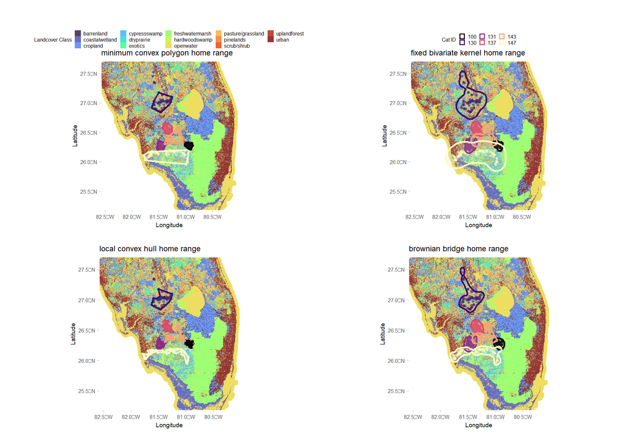

```r
cowplot::plot_grid(
  plotlist = list(
    plt_minimum_convex_polygon
    , plt_fixed_bivariate_kernel
    , plt_local_convex_hull
    , plt_brownian_bridge
  )
  , ncol = 2
  , rel_heights = c(1,0.8)
)
```

## Question 6

If you were tasked with presenting the home range of these animals to the Florida Fish and Wildlife Commission, which would you select and why? (2 pts)

# Florida panther resource selection

## Question 7

Within the Fletcher text, there is a distinction made between Design II and Design III resource selection sampling. What is the difference? (4 pts)

While both methodologies aim to classify resource use and availability, the distinction made between Design II and Design III resource selection sampling in [Fletcher and Fortin (2018)](https://link.springer.com/book/10.1007/978-3-030-01989-1) is that Design II considers resource use by individuals compared to availability at the population level while Design III quantifies resource use and availability at the individual level.

## Question 8

Lines 343 reformats the “use” dataframe. What specially does it do? (2 pts)

```r
#use data
use <- raster::extract(layers, panthers)
#reformat
useCatID <- reshape2::dcast(use, CatID~landcover, length, value.var="CatID")
```

the `reshape2::dcast` function reshapes the data from long to wide with the resulting data unique by `CatID` with individual columns for each `landcover` level.

## Question 9

Calculate the Design II and Design III resource selection models. (12 pts)

### data preparation

Count locations by individual panther and landcover type.

```r
#use data
use_by_catid_long <- terra::extract(
    x = land_sub
    , y = panthers |>
      terra::vect()
    , ID = F
  ) |>
  dplyr::rename(landcover_type=1) |>
  dplyr::mutate(CatID = panthers$CatID) |>
  dplyr::count(CatID, landcover_type) |>
  dplyr::left_join(
    landcover_reclass |>
      dplyr::count(changeto,description2) |>
      dplyr::select(-n)
    , by = c("landcover_type"="changeto")
  ) |>
  dplyr::mutate(
    landcover_class = as.factor(description2)
    , landcover_name = make.names(description2)
  )
# pivot long to wide
use_by_catid_wide <- use_by_catid_long |>
  dplyr::arrange(landcover_name, CatID) |>
  tidyr::pivot_wider(
    id_cols = "CatID"
    , names_from = "landcover_name"
    , values_from = "n"
    , values_fill = 0
  )
```

Sample landcover types in raster data for resource availability at 1) the population level (Design II) and 2) the individual panther level (Design III)

```r
####################################
# design II availability (population)
####################################
#get availability points
set.seed(8)
avail_cov_dsn2_long <- terra::spatSample(
    x = land_sub
    , size = 1000
    , method = "random"
    , na.rm = T
    , as.df = TRUE
  ) |>
  dplyr::rename(landcover_type=1) |>
  dplyr::count(landcover_type) |>
  dplyr::left_join(
    landcover_reclass |>
      dplyr::count(changeto,description2) |>
      dplyr::select(-n)
    , by = c("landcover_type"="changeto")
  ) |>
  dplyr::mutate(
    landcover_class = as.factor(description2)
    , landcover_name = make.names(description2)
  )
# pivot long to wide
avail_cov_dsn2_wide <- avail_cov_dsn2_long |>
  dplyr::select(landcover_name,n) |>
  dplyr::arrange(landcover_name) |>
  tidyr::pivot_wider(
    names_from = "landcover_name"
    , values_from = "n"
    , values_fill = 0
  )
# filter out landcovers not observed in use data
# ????? is this the best method???? or should we ensure that cover type is in the use data with 0's
avail_cov_dsn2_wide <- avail_cov_dsn2_wide |>
  dplyr::select(names(use_by_catid_wide |> dplyr::select(-CatID)))

####################################
# design III availability (individual)
####################################
# function to return available cover by catid
avail_cov_fn <- function(catid,nsamp) {
  set.seed(8)
  # get minimum convex polygon
  # dta_temp <- sf::as_Spatial(panthers |> dplyr::filter(CatID==catid))
  dta_temp <- panthers |> dplyr::filter(CatID==catid) |> dplyr::select(geometry)
  mcp <- adehabitatHR::mcp(
      dta_temp |> sf::as_Spatial()
      , percent = 99
    ) |>
    sf::st_as_sf()
  # sample points within minimum convex polygon
  pts_sample <- sf::st_sample(x = mcp, size = nsamp, type = "random")
  # get landcover values at points from raster
  avail_cov <- terra::extract(
      x = land_sub
      , y = pts_sample |> terra::vect()
      , ID = F
    ) |>
    dplyr::rename(landcover_type=1) |>
    dplyr::mutate(CatID = catid) |>
    dplyr::count(CatID, landcover_type)
  return(avail_cov)
}
# map over all cats
avail_cov_dsn3_long <- unique(panthers$CatID) |>
  purrr::map(avail_cov_fn, nsamp=400) |>
  dplyr::bind_rows() |>
  dplyr::left_join(
    landcover_reclass |>
      dplyr::count(changeto,description2) |>
      dplyr::select(-n)
    , by = c("landcover_type"="changeto")
  ) |>
  dplyr::mutate(
    landcover_class = as.factor(description2)
    , landcover_name = make.names(description2)
  )
# pivot long to wide
avail_cov_dsn3_wide <- avail_cov_dsn3_long |>
  dplyr::arrange(landcover_name, CatID) |>
  tidyr::pivot_wider(
    id_cols = "CatID"
    , names_from = "landcover_name"
    , values_from = "n"
    , values_fill = 0
  )
# filter out landcovers not observed in use data
# ????? is this the best method???? or should we ensure that cover type is in the use data with 0's
avail_cov_dsn3_wide <- avail_cov_dsn3_wide |>
  dplyr::select(names(use_by_catid_wide))
```

selection ratios

```r
############################
# Design II:
############################
sel_ratio_dsn2 <- adehabitatHS::widesII(
  u = use_by_catid_wide |> dplyr::select(-CatID)
  , a = avail_cov_dsn2_wide |> as.matrix() |> as.vector()
  , avknown = FALSE
  , alpha = 0.05
)
#create data frame of results
sel_ratio_dsn2_df <- data.frame(
    landcover_name = row.names(as.data.frame(sel_ratio_dsn2$wi))
    , avail.prop = sel_ratio_dsn2$avail.prop
    , used.prop = sel_ratio_dsn2$used.prop
    , wi = sel_ratio_dsn2$wi # Manly selectivity measure
    , ICwilower = sel_ratio_dsn2$ICwilower
    , ICwiupper = sel_ratio_dsn2$ICwiupper
    , se.wi = sel_ratio_dsn2$se.wi
  ) |>
  dplyr::mutate(
    is_signif = dplyr::case_when(
      ICwilower > 0 & ICwiupper > 0 ~ 1
      , ICwilower < 0 & ICwiupper < 0 ~ 1
      , TRUE ~ 0
    )
    , signif_type = dplyr::case_when(
      ICwilower > 0 & ICwiupper > 0 ~ "Positive"
      , ICwilower < 0 & ICwiupper < 0 ~ "Negative"
      , TRUE ~ "Not Significant"
    )
  )
############################
# Design III:
############################
sel_ratio_dsn3 <- adehabitatHS::widesIII(
  u = use_by_catid_wide |> dplyr::arrange(CatID) |> dplyr::select(-CatID)
  , a = avail_cov_dsn3_wide |> dplyr::arrange(CatID) |> dplyr::select(-CatID)
  , avknown = FALSE
  , alpha = 0.05
)

#create data frame of results
sel_ratio_dsn3_df <- data.frame(
  landcover_name = row.names(as.data.frame(sel_ratio_dsn3$wi))
  , wi = sel_ratio_dsn3$wi # Manly selectivity measure
  , ICwilower = sel_ratio_dsn3$ICwilower
  , ICwiupper = sel_ratio_dsn3$ICwiupper
  , se.wi = sel_ratio_dsn3$se.wi
) |>
  dplyr::mutate(
    is_signif = dplyr::case_when(
      ICwilower > 0 & ICwiupper > 0 ~ 1
      , ICwilower < 0 & ICwiupper < 0 ~ 1
      , TRUE ~ 0
    )
    , signif_type = dplyr::case_when(
      ICwilower > 0 & ICwiupper > 0 ~ "Positive"
      , ICwilower < 0 & ICwiupper < 0 ~ "Negative"
      , TRUE ~ "Not Significant"
    )
  )
```

### part a)

For Design II, are all panthers using the habitats identically? Hint, explore the output of the “widesII”.

```r
sel_ratio_dsn2$Khi2L1 |>
  kableExtra::kable(
      format = "html"
      , caption = "Test of identical use of habitat by all animals<br>Classical Khi-2 performed on the used matrix:"
      , escape = FALSE
      , digits = 3
      , col.names = ""
    ) |>
    kable_styling(font_size = 14)
```

Test of identical use of habitat by all animals Classical Khi-2 performed on the used matrix:

| Khi2L1 | 466.339 |
| --- | --- |
| df | 60.000 |
| pvalue | 0.000 |

Based on the results of the classical Khi-2 test of identical use of habitat by all animals presented above, we reject the null hypothesis of identical habitat use by all panthers.

### part b)

For Design II, which habitats are showing a positive selection? Do any habitats show a significant positive association?

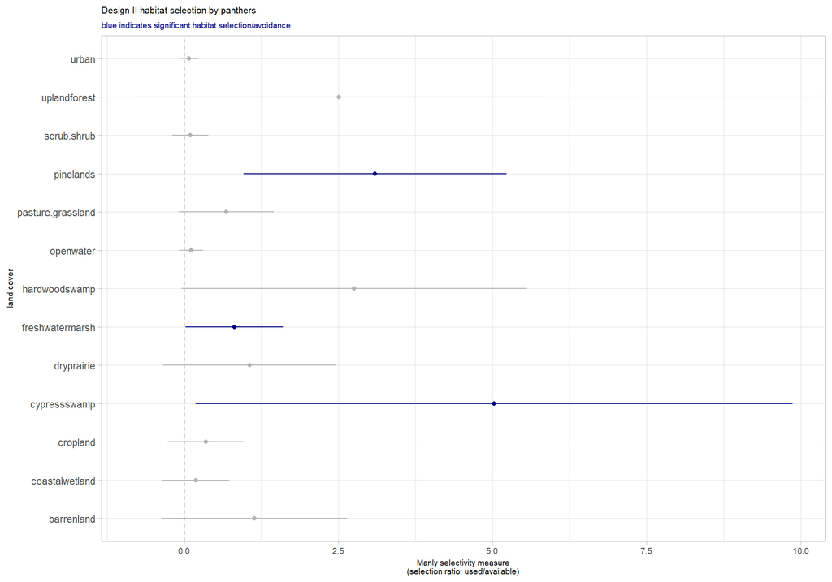

```r
plt_sel_dsn2 <- ggplot(data = sel_ratio_dsn2_df, mapping = aes(y = landcover_name)) +
  geom_vline(xintercept = 0, linetype = "dashed", color = "firebrick") +
  geom_linerange(
    mapping = aes(xmin = ICwilower, xmax = ICwiupper, color = as.factor(is_signif))
  ) +
  geom_point(
    mapping = aes(x = wi, color = as.factor(is_signif))
  ) +
  scale_color_manual(values = c("gray70", "navy") ) +
  labs(
    x = "Manly selectivity measure\n(selection ratio: used/available)"
    , y = "land cover"
    , subtitle = "blue indicates significant habitat selection/avoidance"
    , title = "Design II habitat selection by panthers"
  ) +
  theme_light() +
  theme(
    legend.position = "none"
    , plot.subtitle = element_text(color = "navy", size = 7)
    , plot.title = element_text(size = 8)
    , axis.title.y = element_text(size = 7)
    , axis.text.x =  element_text(size = 7)
    , axis.title.x =  element_text(size = 7)
  )
plt_sel_dsn2
```

Based on the plot above using Design II resource use and availability classification, there are **3** habitats that show positive selection by panthers based on the Manly selectivity measure. These include: **cypressswamp, freshwatermarsh, pinelands**.

### part c)

For Design III, which habitats are showing a positive selection? Do you see negative associations?

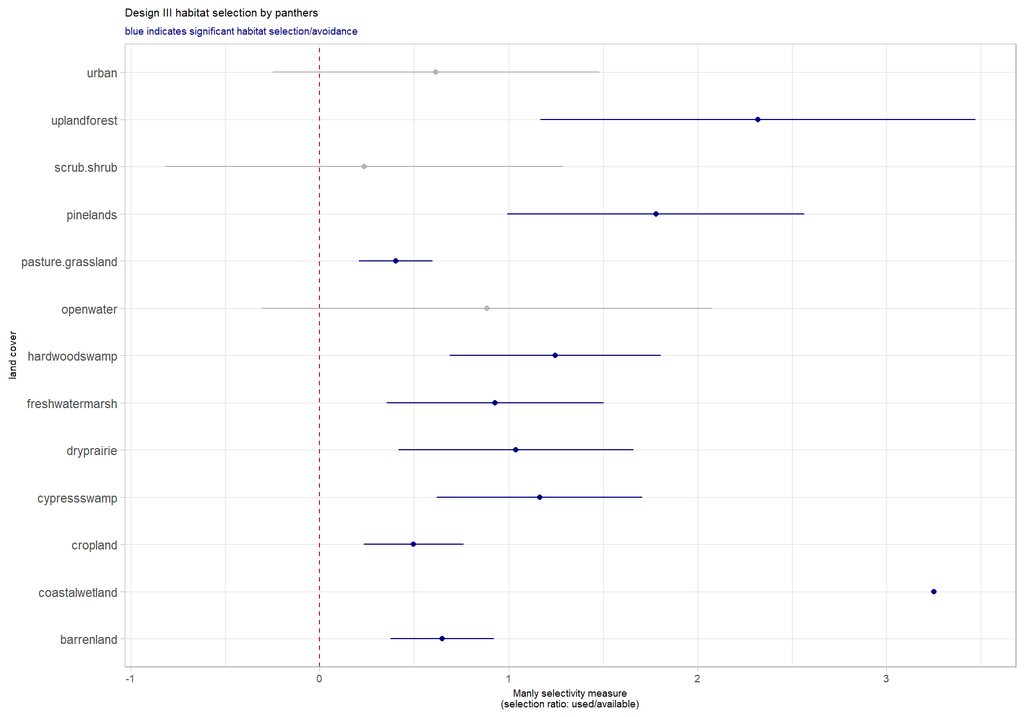

```r
plt_sel_dsn3 <- ggplot(data = sel_ratio_dsn3_df, mapping = aes(y = landcover_name)) +
  geom_vline(xintercept = 0, linetype = "dashed", color = "firebrick") +
  geom_linerange(
    mapping = aes(xmin = ICwilower, xmax = ICwiupper, color = as.factor(is_signif))
  ) +
  geom_point(
    mapping = aes(x = wi, color = as.factor(is_signif))
  ) +
  scale_color_manual(values = c("gray70", "navy") ) +
  labs(
    x = "Manly selectivity measure\n(selection ratio: used/available)"
    , y = "land cover"
    , subtitle = "blue indicates significant habitat selection/avoidance"
    , title = "Design III habitat selection by panthers"
  ) +
  theme_light() +
  theme(
    legend.position = "none"
    , plot.subtitle = element_text(color = "navy", size = 7)
    , plot.title = element_text(size = 8)
    , axis.title.y = element_text(size = 7)
    , axis.text.x =  element_text(size = 7)
    , axis.title.x =  element_text(size = 7)
  )
plt_sel_dsn3
```

Based on the plot above using Design III resource use and availability classification, there are **10** habitats that show positive selection by panthers based on the Manly selectivity measure. These include: **barrenland, coastalwetland, cropland, cypressswamp, dryprairie, freshwatermarsh, hardwoodswamp, pasture.grassland, pinelands, uplandforest**. There are **0** habitats that show significant negative selection by panthers (i.e. avoidance) based on the Manly selectivity measure.

### part d)

What differences do you see comparing the Design II and Design III global results for habitat selection?

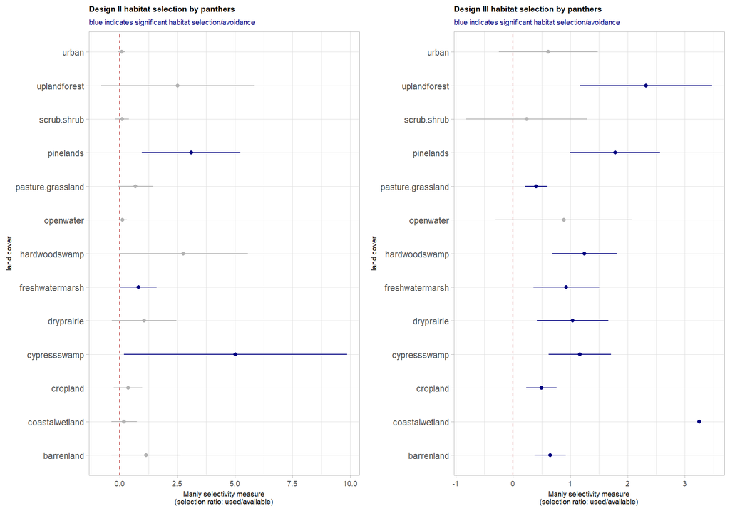

```r
cowplot::plot_grid(
  plotlist = list(
    plt_sel_dsn2 + theme(plot.title = element_text(face = "bold"))
    , plt_sel_dsn3 + theme(plot.title = element_text(face = "bold"))
  )
)
```

```r
# combine data
dta_temp <- dplyr::inner_join(
    sel_ratio_dsn2_df
    , sel_ratio_dsn3_df
    , by = join_by(landcover_name)
  )
```

Based on the comparison between Design II and Design III results for habitat selection, there are **7** land cover types that show significant positive selection by panthers in Design III but not in Design II. These types include: **barrenland, coastalwetland, cropland, dryprairie, hardwoodswamp, pasture.grassland, uplandforest**.